# R package forecastcalibration

This package accompanies the paper `Score-based calibration testing for multivariate forecast distributions’ by Malte Knüppel, Fabian Krüger and Marc-Oliver Pohle:

The package’s main functions are as follows:

- `score_calibration_es` computes the quantities *Û*<sub>ES, *t*</sub> and *D̂*<sub>ES, *t*</sub> for the test versions based on the Energy Score
- `knueppel_test` implements the uniformity test by Knüppel (JBES, 2015) that allows for time dependence under the H0
- `t_hac` implements a HAC robust t-test

## Installation

To install the package from GitHub, please run:

```r
# install.package(remotes)
remotes::install_github("FK83/forecastcalibration")
```

Note that the package contains C++ code, so that Windows users may need to install the Rtools suite provided by CRAN.

## Example

This toy example simulates `n` IID time periods. The forecast distribution is H0 considered in the simulation study of Section 4 in the paper; the true distribution is given by H1. Note that auto-calibration is violated here, so it is desirable for the tests to reject with a small *p*-value.

```r
library(mvtnorm)
library(forecastcalibration)

set.seed(1)

# Dimension of data (nr of variables)
d <- 4
# Sample size (nr of time periods)
n <- 500
# Nr of forecast draws (for each of n periods)
J <- 5e3

# forecast covariance matrix (corresponding to H0 in Section 4 of the paper)
sig_fc <- matrix(.5, d, d)
diag(sig_fc) <- 1

# true covariance matrix (H1 in Section 4)
sig_true <- sig_fc
diag(sig_true) <- (1.1)^2

# simulate outcomes for n time periods
y <- rmvnorm(n, sigma = sig_true)

# initialize vectors to store calibration stats for each period
u <- d <- rep(NA, n)

# loop over time
for (tt in 1:n){
  # Simulate forecast distribution for current period (J draws)
  x <- rmvnorm(J, sigma = sig_fc)
  # Compute U and D for energy score in current period
  es_tmp <- score_calibration_es(y[tt, ], t(x), exact = FALSE)
  u[tt] <- es_tmp$u
  d[tt] <- es_tmp$d
}

# Run calibration tests
knueppel_test(u) # PIT-based test (Generalized Box Transform)
```

```
## $stat
##          [,1]
## [1,] 51.85725
##
## $pval
##              [,1]
## [1,] 1.477595e-10
##
## $nlags_odd
## [1] 3
##
## $nlags_even
## [1] 3
##
## $moments
## [1] "1234"
```

```r
t_hac(d) # Entropy test
```

```
## $t
##          [,1]
## [1,] 7.031735
##
## $k
## [1] 2
##
## $pval
##              [,1]
## [1,] 2.039811e-12
```

## Calibration plot

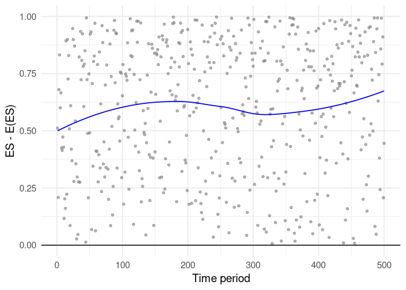

```r
# load ggplot2 package
library(ggplot2)

# make plot
ggplot(data.frame(t = 1:n, u = u), aes(x = t, y = u)) +
  xlab("Time period") + ylab("ES - E(ES)") +
  geom_point(pch = 20, col = grey(.5, .6), size = I(2)) +
  theme_minimal(base_size = 14) +
  geom_hline(yintercept = 0) +
  geom_smooth(se = FALSE, color = "blue2", size = I(.6))
```